# Exam 2

Sean Schilk

11/31/2025

# 1

Read in the data set called Exam2Data.csv. This data set contains 14 measurements on 178 wines from Italy. Unless instructed otherwise, use 5-fold CV and set.seed(1) in the following problems.

```r
setwd("~/STA419/REDO/10.RegressionTrees")

Italy <- read.csv("Exam2Data.csv")
str(Italy)
```

```
## 'data.frame':    178 obs. of  14 variables:
##  $ Region        : chr  "A" "A" "A" "A" ...
##  $ Alcohol       : num  14.2 13.2 13.2 14.4 13.2 ...
##  $ MalicAcid     : num  1.71 1.78 2.36 1.95 2.59 1.76 1.87 2.15 1.64 1.35 ...
##  $ Ash           : num  2.43 2.14 2.67 2.5 2.87 2.45 2.45 2.61 2.17 2.27 ...
##  $ Alcalinity    : num  15.6 11.2 18.6 16.8 21 15.2 14.6 17.6 14 16 ...
##  $ Magnesium     : int  127 100 101 113 118 112 96 121 97 98 ...
##  $ Phenols       : num  2.8 2.65 2.8 3.85 2.8 3.27 2.5 2.6 2.8 2.98 ...
##  $ Flavanoids    : num  3.06 2.76 3.24 3.49 2.69 3.39 2.52 2.51 2.98 3.15 ...
##  $ Nonflavanoid  : num  0.28 0.26 0.3 0.24 0.39 0.34 0.3 0.31 0.29 0.22 ...
##  $ Proanth       : num  2.29 1.28 2.81 2.18 1.82 1.97 1.98 1.25 1.98 1.85 ...
##  $ ColorIntensity: num  5.64 4.38 5.68 7.8 4.32 6.75 5.25 5.05 5.2 7.22 ...
##  $ Hue           : num  1.04 1.05 1.03 0.86 1.04 1.05 1.02 1.06 1.08 1.01 ...
##  $ OD280         : num  3.92 3.4 3.17 3.45 2.93 2.85 3.58 3.58 2.85 3.55 ...
##  $ Proline       : int  1065 1050 1185 1480 735 1450 1290 1295 1045 1045 ...
```

# 2

Load the tidyverse and caret packages. Let’s use Proline as our response variable and the rest of them as explanatory variables. Fit an OLS regression model. Interpret the coefficient for the ColorIntensity, RegionB, and RegionC.

```r
library(caret)
library(tidyverse)

summary(Italy$Proline)
```

```
##    Min. 1st Qu.  Median    Mean 3rd Qu.    Max.
##   278.0   500.5   673.5   746.9   985.0  1680.0
```

```r
fitControl <- trainControl(method = "cv", number = 5)
set.seed(1)
model.lm <- train(Proline ~ .,
                  method = "lm",
                  data = Italy,
                  trControl = fitControl)

summary(model.lm)
```

```
##
## Call:
## lm(formula = .outcome ~ ., data = dat)
##
## Residuals:
##     Min      1Q  Median      3Q     Max
## -369.50  -92.02   -1.79   94.53  446.65
##
## Coefficients:
##                Estimate Std. Error t value Pr(>|t|)
## (Intercept)     502.560    392.856   1.279   0.2026
## RegionB        -506.343     58.977  -8.586 6.88e-15 ***
## RegionC        -513.535     91.096  -5.637 7.45e-08 ***
## Alcohol          18.659     25.689   0.726   0.4687
## MalicAcid       -16.079     14.441  -1.113   0.2672
## Ash               6.000     70.349   0.085   0.9321
## Alcalinity       -1.205      5.941  -0.203   0.8395
## Magnesium         1.789      1.002   1.786   0.0760 .
## Phenols          54.315     40.758   1.333   0.1845
## Flavanoids      -54.122     37.648  -1.438   0.1525
## Nonflavanoid    -54.780    132.901  -0.412   0.6807
## Proanth          34.304     29.895   1.147   0.2529
## ColorIntensity   24.828     10.180   2.439   0.0158 *
## Hue             184.853     85.672   2.158   0.0324 *
## OD280           -54.195     35.590  -1.523   0.1298
## ---
## Signif. codes:  0 '***' 0.001 '**' 0.01 '*' 0.05 '.' 0.1 ' ' 1
##
## Residual standard error: 161.4 on 163 degrees of freedom
## Multiple R-squared:  0.7582, Adjusted R-squared:  0.7374
## F-statistic: 36.51 on 14 and 163 DF,  p-value: < 2.2e-16
```

We expect the response Proline to increase by 24.828 on average, for a 1 unit increase in ColorIntensity holding all other variables constant.

We expect Proline to decrease by 506.343 on average, when comparing region B to region A, holding all other variables constant.

We expect Proline to decrease by 513.535 on average, when comparing region C to region A, holding all other variables constant.

# 3

What was your TEST RMSE using OLS regression. Interpret this value.

```r
model.lm
```

```
## Linear Regression
##
## 178 samples
##  13 predictor
##
## No pre-processing
## Resampling: Cross-Validated (5 fold)
## Summary of sample sizes: 142, 143, 142, 143, 142
## Resampling results:
##
##   RMSE      Rsquared   MAE
##   168.0626  0.7333614  129.8525
##
## Tuning parameter 'intercept' was held constant at a value of TRUE
```

Test RMSE = 168.0626. This means that our predicted values of the held out test observations are off by an average of 168.0626 units.

# 4

Now, let’s use the LASSO instead. Use the same response variable and the original data set. Set your lambda tuning parameter grid to be: 10^seq(-2, 1, length = 25). What is your test RMSE? Did you do better or worse than OLS regression? Were any of your coefficient estimates set to 0?

```r
tune.grid <- expand.grid(alpha = 1,
                         lambda = 10^seq(-2, 1, length = 25))

set.seed(1)
model.lasso <- train(Proline ~ .,
                       data = Italy,
                       method = "glmnet",
                       trControl = fitControl,
                       tuneGrid = tune.grid)

model.lasso # Gives a similar test RMSE but a different lambda
```

```
## glmnet
##
## 178 samples
##  13 predictor
##
## No pre-processing
## Resampling: Cross-Validated (5 fold)
## Summary of sample sizes: 142, 143, 142, 143, 142
## Resampling results across tuning parameters:
##
##   lambda       RMSE      Rsquared   MAE
##    0.01000000  167.7167  0.7343222  129.7797
##    0.01333521  167.7167  0.7343222  129.7797
##    0.01778279  167.7167  0.7343222  129.7797
##    0.02371374  167.7167  0.7343222  129.7797
##    0.03162278  167.7167  0.7343222  129.7797
##    0.04216965  167.7167  0.7343222  129.7797
##    0.05623413  167.7167  0.7343222  129.7797
##    0.07498942  167.7167  0.7343222  129.7797
##    0.10000000  167.7167  0.7343222  129.7797
##    0.13335214  167.7167  0.7343222  129.7797
##    0.17782794  167.7144  0.7343355  129.8004
##    0.23713737  167.7047  0.7343841  129.8424
##    0.31622777  167.6579  0.7345308  129.8712
##    0.42169650  167.5510  0.7348530  129.8712
##    0.56234133  167.4477  0.7351406  129.8815
##    0.74989421  167.3700  0.7353262  129.9154
##    1.00000000  167.3575  0.7352228  130.0115
##    1.33352143  167.4027  0.7348441  130.3183
##    1.77827941  167.4069  0.7346477  130.5143
##    2.37137371  167.4025  0.7344871  130.6858
##    3.16227766  167.4484  0.7346740  130.9283
##    4.21696503  167.7314  0.7346227  131.4540
##    5.62341325  167.8945  0.7350463  132.0989
##    7.49894209  168.1832  0.7352647  132.8636
##   10.00000000  169.0439  0.7338634  134.1911
##
## Tuning parameter 'alpha' was held constant at a value of 1
## RMSE was used to select the optimal model using the smallest value.
## The final values used for the model were alpha = 1 and lambda = 1.
```

```r
coef(model.lasso$finalModel, model.lasso$bestTune$lambda)
```

```
## 15 x 1 sparse Matrix of class "dgCMatrix"
##                        s=1
## (Intercept)     443.149261
## RegionB        -490.197639
## RegionC        -463.686677
## Alcohol          20.953077
## MalicAcid       -16.549620
## Ash               .
## Alcalinity       -1.820390
## Magnesium         1.891681
## Phenols          39.328029
## Flavanoids      -31.179574
## Nonflavanoid    -20.234327
## Proanth          28.384624
## ColorIntensity   22.840434
## Hue             179.450370
## OD280           -43.950958
```

Our test RMSE here is 167.3575. We did slightly better than OLS regression, which had a test RMSE of 168.0626. The coefficient for the variable Ash was set to 0.

# 5

Now, fit a regression tree without pruning the tree. What was your test RMSE?

```r
fitControl <- trainControl(method = "cv", number = 5)
set.seed(1)

cpGrid <- expand.grid(cp = 0) # No pruning

model.tree <- train(Proline ~ .,
                    data = Italy,
                    method = "rpart",
                    trControl = fitControl,
                    tuneGrid = cpGrid)

model.tree
```

```
## CART
##
## 178 samples
##  13 predictor
##
## No pre-processing
## Resampling: Cross-Validated (5 fold)
## Summary of sample sizes: 142, 143, 142, 143, 142
## Resampling results:
##
##   RMSE      Rsquared   MAE
##   207.6316  0.6052025  155.0814
##
## Tuning parameter 'cp' was held constant at a value of 0
```

We get a test RMSE of 207.6316 here, which is our worst yet by a large margin.

# 6

Let the train( ) function prune the tree using 10 possible tuning parameter values. Now, what was your test RMSE? Explain why pruning the tree reduced this value.

```r
model.tree.prune <- train(Proline ~ .,
                    data = Italy,
                    method = "rpart",
                    trControl = fitControl,
                    tuneLength = 10) # Let function pick 10 reasonable tuning parameters to prune the tree

model.tree.prune
```

```
## CART
##
## 178 samples
##  13 predictor
##
## No pre-processing
## Resampling: Cross-Validated (5 fold)
## Summary of sample sizes: 142, 143, 143, 142, 142
## Resampling results across tuning parameters:
##
##   cp           RMSE      Rsquared   MAE
##   0.006601359  200.2855  0.6098777  153.9185
##   0.006986084  200.2855  0.6098777  153.9185
##   0.009307939  201.3970  0.6053814  155.3069
##   0.016875970  199.7966  0.6125292  153.2394
##   0.021290988  196.9406  0.6186760  152.8582
##   0.021983889  196.9406  0.6186760  152.8582
##   0.037897587  201.5335  0.6037690  156.7089
##   0.045545156  201.0051  0.6047043  155.6309
##   0.235570070  245.8894  0.4043047  183.4692
##   0.376338227  297.6308  0.2222191  234.1649
##
## RMSE was used to select the optimal model using the smallest value.
## The final value used for the model was cp = 0.02198389.
```

By decreasing the number of terminal nodes, we decrease the variance of the model because we must make fewer decisions. This resulted in a smaller test RMSE.

# 7

Plot the pruned tree from the previous part. Explain where each of the numbers in the terminal nodes are coming from. Verify these are correct.

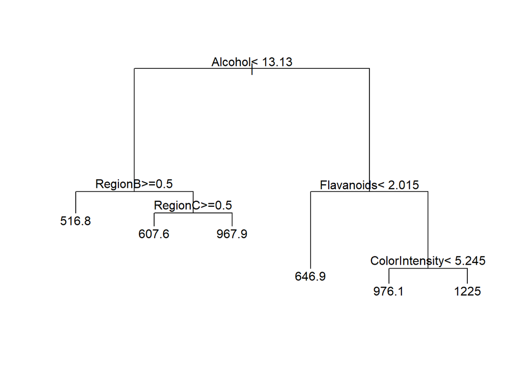

```r
par(xpd = NA)
plot(model.tree.prune$finalModel)
text(model.tree.prune$finalModel)
```

```r
Italy %>%
  filter(Alcohol < 13.13) %>%
  summarize(mean.pro = mean(Proline), n = n())
```

| mean.pro | n |
| --- | --- |
| 570.8557 | 97 |

```r
Italy %>%
  filter(Alcohol >= 13.13, Flavanoids < 2.015) %>%
  summarize(mean.pro = mean(Proline), n = n())
```

| mean.pro | n |
| --- | --- |
| 646.8571 | 28 |

```r
Italy %>%
  filter(Alcohol >= 13.13, Flavanoids >= 2.015, ColorIntensity < 5.245) %>%
  summarize(mean.pro = mean(Proline), n = n())
```

| mean.pro | n |
| --- | --- |
| 976.1364 | 22 |

```r
Italy %>%
  filter(Alcohol >= 13.13, Flavanoids >= 2.015, ColorIntensity >= 5.245) %>%
  summarize(mean.pro = mean(Proline), n = n())
```

| mean.pro | n |
| --- | --- |
| 1225.387 | 31 |

we can verify we get the correct values in the terminal nodes by taking the average response of all the observations that fell in each of the terminal nodes.

# 8

Now, let’s verify why the regression tree chose the variable and value to make the first split. What is the training MSE with no splits? What is the training MSE after making a split on the first variable and value. Did you do better or worse than no splits?

```r
# No splitting

yhat.no <- mean(Italy$Proline)
mse.no <- mean((yhat.no - Italy$Proline)^2)
  mse.no
```

```
## [1] 98609.6
```

```r
# Actual first split

yhat.1 <- ifelse(Italy$Alcohol < 13.13,
              mean(Italy$Proline[which(Italy$Alcohol < 13.13)]),
              mean(Italy$Proline[which(Italy$Alcohol >= 13.13)]))
mse.1 <- mean((yhat.1 - Italy$Proline)^2)
  mse.1
```

```
## [1] 61499.04
```

The training MSE with no splits is 98609.6, while the training MSE after making a split on the first variable and value is significantly lower, 61499.04. Therefore we did better than no splits here.

# 9

Pick a different value for that variable. Verify that the training MSE using this new value is, in fact, greater than the training MSE using the original value.

```r
# Split on Different Alcohol Value

yhat.2 <- ifelse(Italy$Alcohol < 14,
              mean(Italy$Proline[which(Italy$Alcohol < 14)]),
              mean(Italy$Proline[which(Italy$Alcohol >= 14)]))
mse.2 <- mean((yhat.2 - Italy$Proline)^2)
  mse.2
```

```
## [1] 78679.92
```

We can see here the training MSE is greater, 78679.92, with a different value for our split than the optimally chosen one.

# 10

Now, pick a different variable (and value) that is used at a later split in the tree. Verify the training MSE using this new variable and value is still higher than what was chosen in the pruned tree.

```r
# Splitting on Flavanoids instead of Alcohol, with different value than optimal

yhat.3 <- ifelse(Italy$Flavanoids < 5,
              mean(Italy$Proline[which(Italy$Flavanoids < 5)]),
              mean(Italy$Proline[which(Italy$Flavanoids >= 5)]))
mse.3 <- mean((yhat.3 - Italy$Proline)^2)
  mse.3
```

```
## [1] 98160.65
```

Again, our training MSE choosing both a different variable and value that was used at a later split increased.

# 11

Run a random forest model using m = 2, 3, 4, 5, 6. What was your optimal value of m? What was the test RMSE using this model? Did we do better or worse than the previous models?

```r
mtryGrid <- expand.grid(mtry = 2:6)

set.seed(1)

model.rf <- train(Proline ~ .,
                  data = Italy,
                  method = "rf",
                  trControl = fitControl,
                  tuneGrid = mtryGrid)

  model.rf
```

```
## Random Forest
##
## 178 samples
##  13 predictor
##
## No pre-processing
## Resampling: Cross-Validated (5 fold)
## Summary of sample sizes: 142, 143, 142, 143, 142
## Resampling results across tuning parameters:
##
##   mtry  RMSE      Rsquared   MAE
##   2     161.4962  0.7626901  128.5825
##   3     160.4413  0.7615972  128.5710
##   4     160.6688  0.7583298  128.3749
##   5     158.9645  0.7614450  127.1287
##   6     161.2220  0.7525361  128.2200
##
## RMSE was used to select the optimal model using the smallest value.
## The final value used for the model was mtry = 5.
```

Our optimal value of m here is 5, with a test RMSE of 158.9645. This is our lowest test RMSE and therefore our best model yet.

# 12

Explain one disadvantage of random forest models as opposed to individual trees. Explain how we can still find this information.

One distinct disadvantage to using random forests is that we don’t have one decision tree to look at. So we don’t necessarily know which variables were used to make the decisions. However, we can aggregate over all the trees. In each tree, we can see how much RMSE we saved from splitting on the variables. Then, we can add that up for all the variables over all the trees. The variables that were chosen earlier and more often can be considered the most **important** variables in terms of the relationship with the response.

```r
varImp(model.rf)
```

```
## rf variable importance
##
##                 Overall
## Flavanoids     100.0000
## Alcohol         88.2121
## RegionB         53.2055
## Phenols         33.4460
## ColorIntensity  29.0779
## Magnesium       28.5244
## OD280           25.8280
## Alcalinity      19.2123
## Hue             11.1534
## MalicAcid        3.2532
## RegionC          2.7129
## Proanth          2.6800
## Ash              0.9417
## Nonflavanoid     0.0000
```

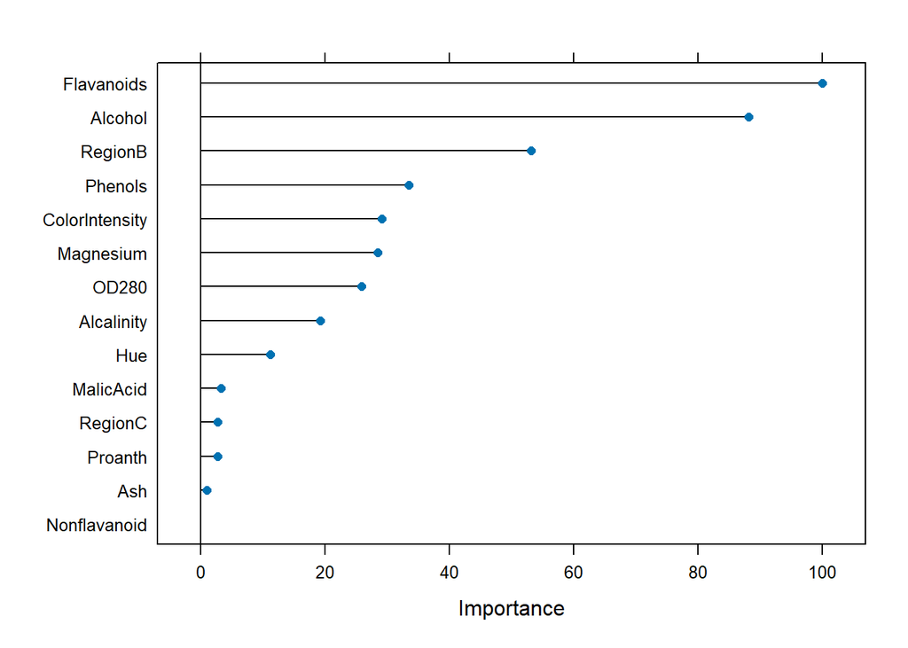

```r
plot(varImp(model.rf) )
```

```r
varImp(model.rf, scale = FALSE)
```

```
## rf variable importance
##
##                Overall
## Flavanoids     3534379
## Alcohol        3154568
## RegionB        2026642
## Phenols        1389984
## ColorIntensity 1249239
## Magnesium      1231407
## OD280          1144526
## Alcalinity      931365
## Hue             671706
## MalicAcid       417159
## RegionC         399750
## Proanth         398688
## Ash             342680
## Nonflavanoid    312339
```

Flavanoids was our most important variable here.

# 13

For the rest of the questions, we use do classification. Now Region is your response variable (instead of Proline). Run KNN with k = 1, . . . 13. What was your optimal value of k? What was the test accuracy using this model? Interpret this value.

```r
fitControl <- trainControl(method = "cv", number = 5, classProbs = TRUE, savePredictions = "all") # saving predictions for all 10 folds

kGrid <- expand.grid(k = seq(1, 13, by = 2))

set.seed(1)
model.knn <- train(data = Italy,
                   Region ~ .,
                   method = "knn",
                   tuneGrid = kGrid,
          #         preProc = c("center", "scale"),
                   trControl = fitControl)

  model.knn
```

```
## k-Nearest Neighbors
##
## 178 samples
##  13 predictor
##   3 classes: 'A', 'B', 'C'
##
## No pre-processing
## Resampling: Cross-Validated (5 fold)
## Summary of sample sizes: 141, 143, 143, 143, 142
## Resampling results across tuning parameters:
##
##   k   Accuracy   Kappa
##    1  0.7686701  0.6491227
##    3  0.7249850  0.5857240
##    5  0.6970227  0.5413451
##    7  0.7083012  0.5582478
##    9  0.7141742  0.5693017
##   11  0.6857529  0.5298613
##   13  0.6970313  0.5471581
##
## Accuracy was used to select the optimal model using the largest value.
## The final value used for the model was k = 1.
```

Our optimal value of K here is 1, and we got a test accuracy of 0.7687. Therefore our model correctly predicted the region 76.87% of the time.

# 14

Repeat the previous part but now center and scale the variables. Remember that you can do this within the train( ) function. Now what is your test accuracy using the new optimal value of k? Explain why we did so much better here.

```r
set.seed(1)
model.knn2 <- train(data = Italy,
                   Region ~ .,
                   method = "knn",
                   tuneGrid = kGrid,
                   preProc = c("center", "scale"),
                   trControl = fitControl)

  model.knn2
```

```
## k-Nearest Neighbors
##
## 178 samples
##  13 predictor
##   3 classes: 'A', 'B', 'C'
##
## Pre-processing: centered (13), scaled (13)
## Resampling: Cross-Validated (5 fold)
## Summary of sample sizes: 141, 143, 143, 143, 142
## Resampling results across tuning parameters:
##
##   k   Accuracy   Kappa
##    1  0.9604676  0.9403076
##    3  0.9661819  0.9488648
##    5  0.9661819  0.9488648
##    7  0.9604676  0.9402229
##    9  0.9715873  0.9569956
##   11  0.9491978  0.9234248
##   13  0.9604676  0.9402229
##
## Accuracy was used to select the optimal model using the largest value.
## The final value used for the model was k = 9.
```

After centering and scaling, we got an optimal k=9 with a test accuracy of 0.9716. We did better here because centering and scaling ensured all predictors contributed equally to the distance metric, preventing large-scale variables from dominating.

This gave KNN a much more meaningful measure of similarity between observations, resulting in a more accurate and reliable model.

# 15

Now fit a classification tree. Let the train( ) function pick ten different values of the tuning parameter. Plot the final tree. How many terminal nodes did you have? Explain what the ”values” are in the terminal nodes. Verify the terminal node furthest to the left has the correct ”value.

```r
set.seed(1)
model.classtree <- train(Region ~ .,
                    data = Italy,
                    method = "rpart",
                    trControl = fitControl,
                    tuneLength = 10)

model.classtree
```

```
## CART
##
## 178 samples
##  13 predictor
##   3 classes: 'A', 'B', 'C'
##
## No pre-processing
## Resampling: Cross-Validated (5 fold)
## Summary of sample sizes: 141, 143, 143, 143, 142
## Resampling results across tuning parameters:
##
##   cp          Accuracy   Kappa
##   0.00000000  0.9101158  0.8645875
##   0.05503634  0.8929730  0.8376120
##   0.11007269  0.8540669  0.7793865
##   0.16510903  0.8540669  0.7793865
##   0.22014538  0.8540669  0.7793865
##   0.27518172  0.8540669  0.7793865
##   0.33021807  0.8254955  0.7302138
##   0.38525441  0.8026384  0.6908844
##   0.44029076  0.5942257  0.3416148
##   0.49532710  0.4502874  0.0904824
##
## Accuracy was used to select the optimal model using the largest value.
## The final value used for the model was cp = 0.
```

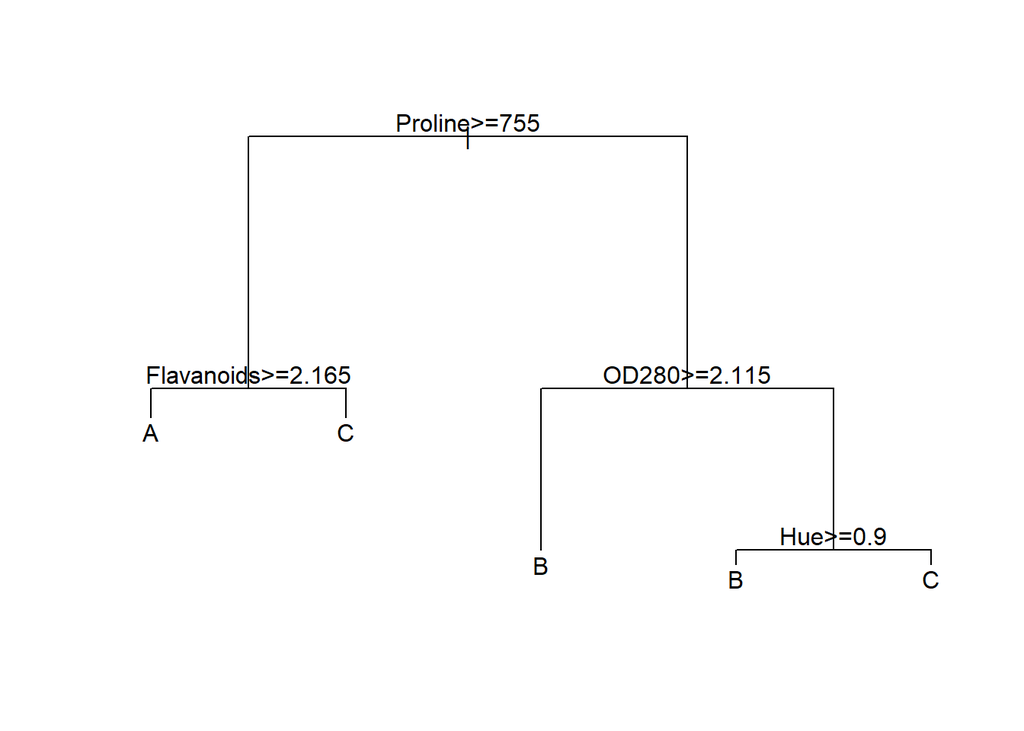

```r
par(xpd = NA)
plot(model.classtree$finalModel)
text(model.classtree$finalModel)
```

There were 5 terminal nodes. We are using “majority rules” here instead of average value as our response is categorical, so they are the region where most of the observations fall.

Let’s verify this for the leftmost node:

```r
Italy %>%
  filter(Proline >= 755,
         Flavanoids >= 2.165,) %>%
  group_by(Region) %>%
  summarize(n = n())
```

| Region | n |
| --- | --- |
| A | 57 |
| B | 2 |

More observations fell into region A than region B, as we can see.

# 16

Explain why we use the Gini Index for classification instead of the RMSE that we use for regression. Compute the Gini Index if we didn’t make any splits.

Instead of choosing variables and cuts to make decisions based on decreasing the RSS, we trying to decrease the **Gini Index**. This gives us a measure of node *purity*. We want our terminal nodes to have mostly just one class.

```r
#No splits
table(Italy$Region)
```

```
##
##  A  B  C
## 59 71 48
```

```r
(59/178)*(1-59/178) +(71/178)*(1-71/178) + (48/178)*(1-48/178)
```

```
## [1] 0.6583133
```

# 17

Compute the Gini Index if we make a split on the first variable and value found at the top of the classification tree. Did we do better or worse than no splits?

```r
Italy %>%
  filter(Proline >= 755) %>% # first split from tree
  group_by(Region) %>%
  summarize(n = n())
```

| Region | n |
| --- | --- |
| A | 57 |
| B | 4 |
| C | 6 |

```r
(57/67)*(1-57/67) +(4/67)*(1-4/67) + (6/67)*(1-6/67)
```

```
## [1] 0.2646469
```

The Gini Index lowers after our first split, so we did better than no splits here.

# 18

Pick a different value of that first variable. Compute the Gini Index. Did we do better or worse than the previous part?

```r
Italy %>%
  filter(Proline >= 500) %>%
  group_by(Region) %>%
  summarize(n = n())
```

| Region | n |
| --- | --- |
| A | 59 |
| B | 33 |
| C | 43 |

```r
(59/135)*(1-59/135) + (33/135)*(1-33/135) + (43/135)*(1-43/135)
```

```
## [1] 0.6477915
```

After switching the value for our first split, we can see we did worse as the GI score increased.

# 19

Pick a different variable (and value) from the tree to make this split. Compute the Gini Index. Which of the four (no split, correct variable and value, different value, and different variable and value) did the best?

```r
Italy %>%
  filter(Hue < 1) %>%
  group_by(Region) %>%
  summarize(n = n())
```

| Region | n |
| --- | --- |
| A | 15 |
| B | 31 |
| C | 48 |

```r
(15/94)*(1-15/94) + (31/94)*(1-31/94) + (48/94)*(1-48/94)
```

```
## [1] 0.6050249
```

Of course the correct variable and value split did the best, having the lowest Gini Index of 0.2646.

# 20

Explain what we mean by Out-Of-Bag (OOB) in bagging. What are two advantages of using OOB instead of CV to get estimates of our test accuracy?

observations that are not included in each replicate when bootstrap resampling are called out-of-bag (OOB) observations.

Using OOB method is much faster computationally as it fits and tests at the same time, while also giving similar results.

# 21

Run a random forest model with m = 1, . . . , 5 as tuning parameters using OOB (instead of CV) to get your test accuracy. What was the optimal value of m? What was your test accuracy? Which two variables were most important in terms of predicting the Region in which the wine came from?

```r
mtryGrid <- expand.grid(mtry = c(1, 2, 3, 4, 5))

set.seed(1)
model.rf.oob <- train(Region ~ .,
                  data = Italy,
                  method = "rf",
                  trControl = trainControl(method = "oob"),
                  tuneGrid = mtryGrid)

model.rf.oob
```

```
## Random Forest
##
## 178 samples
##  13 predictor
##   3 classes: 'A', 'B', 'C'
##
## No pre-processing
## Resampling results across tuning parameters:
##
##   mtry  Accuracy   Kappa
##   1     0.9887640  0.9829608
##   2     0.9887640  0.9829608
##   3     0.9831461  0.9744693
##   4     0.9775281  0.9659395
##   5     0.9775281  0.9659395
##
## Accuracy was used to select the optimal model using the largest value.
## The final value used for the model was mtry = 1.
```

```r
varImp(model.rf.oob)
```

```
## rf variable importance
##
##                Overall
## ColorIntensity 100.000
## Proline         99.562
## Flavanoids      88.910
## OD280           82.530
## Alcohol         73.718
## Hue             55.237
## Phenols         51.700
## MalicAcid       28.300
## Alcalinity      21.934
## Proanth         21.079
## Magnesium       20.801
## Ash              2.441
## Nonflavanoid     0.000
```

We got an optimal value of m = 1, with a test accuracy of 0.9888. ColorIntensity and Proline were the most important variables in terms of predicting which Region the wine came from.